# **Artificial Intelligence for Disentangling Extremes (AIDE) Toolbox**

## Case Study: Impact Assessment of Worldwide Earthquakes

### September 2023

[figure not shown]

Image source: Deformation pattern caused by a seismic event over the L'Aquila area in central Italy. This interferogram was generated by Italy’s Istituto per il Rilevamento Elettromagnetico dell’ Ambiente (IREA-CNR) in Naples, Italy. Registered using an Envisat Advanced Synthetic Aperture Radar (ASAR) on 12 April 2009.

#### Problem definition: This use case focuses on the prediction of the impact that extreme events may have on the population. Specifically, we focus on the normalized total damages due to worldwide earthquakes. To do so, we will use climate data of each region.

#### This notebook aims to provide users with practical experience in utilising the toolbox. This tutorial also aims to provide a guide to tackle regression problems (referred to as Impact Assessment tasks) using 1D datasets.

> To gain a comprehensive understanding of the toolbox's structure and detailed usage instructions, we highly recommend referring to the user guide available in the "Read the Docs" reference. Familiarising yourself with the user guide will ensure you have a solid foundation to make the most out of the tutorial and leverage the toolbox effectively.

## Tutorial workflow

```
1. PREREQUISITES

2. DATA

3. MODEL

4. TRAINING

5. EVALUATION

6. EXPLAINABLE AI
```

## 1. PREREQUISITES OF THE TOOLBOX

Please, start running the following cells to check out the contents of the toolbox, install its dependencies and import the required libraries to make use of it.

```python
%load_ext autoreload
%autoreload 2
```

#### Check out the contents of the AIDE toolbox

```python
a = %pwd

if a.split("/")[-1] != "AIDE":
    %cd ../
%ls -h
```

```
/home/maria/Documents/AIDE_private/AIDE
backbones/  databases/   experiments/  tutorials/     utils/
configs/    evaluators/  main.py*      user_defined/
```

Folders with tunable functionalities:

> - *configs* is a directory including config files with the tuneable parameters regarding the data, architecture, training and evaluation;
> - *databases* stores available example datasets, as well as the datasets for which you would like to use the AIDE toolbox;
> - *tutorials* contains several notebooks to serve as example of usage of the AIDE toolbox;
> - *user_defined* includes the user defined files and functions;

Internal code:

> - *backbones* defines the core classes of the toolbox;
> - *evaluators* creates the necessary modules for a better assessment of results;
> - *utils* contains generic functions used by the toolbox;
> - *main.py* is the main script to execute the pipeline of the toolbox using the command window.

#### Import required libraries

```python
import numpy as np
import matplotlib.pyplot as plt
import pandas as pd
import os
import itertools
from tqdm.auto import tqdm
from datetime import datetime
from scipy.interpolate import interp1d
from sklearn.preprocessing import RobustScaler
import time
import datetime
import seaborn as sns

# PYTORCH
from torch.utils.data import DataLoader
# PYTORCH LIGHTNING
import pytorch_lightning as pl
from pytorch_lightning import loggers as pl_loggers
from pytorch_lightning.callbacks import ModelSummary, ModelCheckpoint, EarlyStopping
# TORCHMETRICS
import torchmetrics

# DATASET CLASSES
from databases import *
# MODEL TEMPLATE CLASS
from  backbones import *
# EVALUATION
from evaluators import *
# METRICS
from utils.misc import *
from utils.setup_config import setup

import yaml
from os.path import dirname, abspath
from pathlib import Path
import sys

import matplotlib as mpl
mpl.rcParams['figure.dpi'] = 300
pd.set_option('display.max_rows', 50)
sns.set_style("darkgrid")
from PIL import Image
```

## 2. DATA

### 2.1 The database

The dataset that we will use is the DATABASE OF EXTREME CLIMATE EVENTS AND ASSOCIATED IMPACTS ON ECOSYSTEMS AND SOCIETY (named XAIDA database in our Git repository) prepared by the members of Universität Leipzig inside the XAIDA project. The database summarizes the reported impacts of extreme climate and weather events listed by EM-DAT and it couples them with two-year time series of climate variables aggregated over the event locations.

Characteristics of the climate data:

- Temporal resolution: Spans from 1989 to 2021 as one year before and after per each event.
- Spatial resolution: 0.25º
- Variables:
  - ERA5 eanalysis data: t2m, t2mmax, t2mmin, tp, pev.
  - Calculated from ERA5: pet, SPEI30, SPEI90, SPEI180
  - GLEAM: smsurf

In more detail: multidimensional array of aggregated climate variables for the disaster events

| # | Coordinates/ dimensions | Description |
| --- | --- | --- |
| 1 | Event | Event identifier corresponding to disaster_number_country in the event data frame.eXtreme events: Artificial Intelligence for Detection and Attribution Database of extreme climate events and associate… |
| 2 | Landcover | The spatial aggregation was performed on the geometry where the disaster was reported, and also on the Urban/ agricultural and natural ecosystem land covers within that geometry |
| 3 | Time | Time axis of each climate variables for each event starting at the day -365 before event onset (corresponding to the start aggregation date in the event data frame), and ending 365 days after event on… |
| 4 | Units | Climatological variables were aggregated per event and land cover type both in original units and normalized anomalies |

| # | Climatological variables | Description |
| --- | --- | --- |
| 1 | pet | Potential evapotranspiration |
| 2 | pev | Potential evaporation (ERA5) |
| 3 | spei_30, spei_90, spei_180 | Standardized Precipitation - Evapotranspiration Index for 30, 90, and 180 days |
| 6 | t2m, t2mmax, t2mmin | 2m Air temperature: daily mean, maximum and minimum (ERA5) |
| 9 | tp | Total daily precipitation (ERA5) |
| 10 | Surface moisture | Surface moisture (GLEAM) |

Societal impact data:

- Human losses: extracted from EM-DAT
- Finantial damages: extracted from EM-DAT
- Population data: the gridded population data GPW3 and GPW4
- GDP data: the product used is the gridded global dataset for Gross Domestic Product (Kummu et al. 2018)

The database has data available from 9 disaster types, further defined by their respective subtypes. The number of events per disaster type considered in the societal dataset and their yearly breakdown are shown in Figure 1 and Figure 2 respectively.

[figure not shown]

### 2.2 Configuration files

Configuration files are essential in deep learning for their ability to separate settings and parameters from the code, promoting modularity and reproducibility. They provide flexibility and customisation options, allowing easy adjustments to hyperparameters, model architectures, and other aspects.

```python
YOUR_CONFIG_FILE_NAME = "config_XAIDA_Earthquakes_IA"

EXPERIMENT_ID = "jupyter_" + YOUR_CONFIG_FILE_NAME.split("_")[1] + "_"+ YOUR_CONFIG_FILE_NAME.split("_")[2] + "_" + str(time.time())
current_d = dirname(abspath("__file__"))
config_path = current_d + "/configs/" + YOUR_CONFIG_FILE_NAME + ".yaml"
config = setup(config_path)
config['experiment_id'] = EXPERIMENT_ID
```

We first load the default configuration to visualize them:

```python
config
```

```
{'name': 'AIDE',
 'task': 'ImpactAssessment',
 'from_scratch': True,
 'best_run_path': '',
 'save_path': 'experiments/',
 'debug': False,
 'data': {'name': 'XAIDA_IA',
  'seed': 42,
  'data_dim': 1,
  'root': './databases/XAIDA/',
  'index_data': 'index_data/xaida_impacts_disaster_dataframe.csv',
  'clim_data': 'clim_data/DB_extreme_clim_events_impacts.zarr/',
  'num_targets': 1,
  'whole_ts': False,
  'random_lead_time': 0,
  'before_event': -5,
  'after_event': 5,
  'event_duration': 1,
  'steps_per_batch': 'all',
  'landcover': ['urban', 'natural'],
  'input_size': 10,
  'train_slice': {'start': 1989, 'end': 2010},
  'val_slice': {'start': 2011, 'end': 2014},
  'test_slice': {'start': 2015, 'end': 2021},
  'units': 'original',
  'impact_var': 'normalized_total_damages',
  'extremes': ['Earthquake'],
  'continents': ['Asia', 'Africa', 'Americas', 'Europe', 'Oceania'],
  'features': ['pet',
   'pev',
   'spei_30',
   'spei_90',
   'spei_180',
   't2m',
   't2mmax',
   't2mmin',
   'tp',
   'smsurf',
   'label'],
  'features_selected': [0, 1, 2, 3, 4, 5, 6, 7, 8, 9],
```

[output cut: 20 more lines]

```
   'gclip_value': -1},
  'trainer': {'accelerator': 'cpu',
   'devices': 1,
   'epochs': 1000,
   'batch_size': 16,
   'monitor': {'split': 'val', 'metric': 'loss'},
   'monitor_mode': 'min',
   'early_stop': 50,
   'save_dir': 'experiments/'},
  'data_loader': {'num_workers': 16, 'sampler': 'None'}},
 'evaluation': {'metrics': {'MeanSquaredError': {},
   'PearsonCorrCoef': {},
   'SpearmanCorrCoef': {}},
  'xai': {'activate': True, 'params': {'type': 'Saliency', 'params': None}}},
 'experiment_id': 'jupyter_XAIDA_Earthquakes_1694256291.7084587'}
```

```python
#Modify config parameters: Data preprocessor
train_start, train_end= 1989, 2010
val_start, val_end= 2011, 2014
test_start, test_end= 2015, 2021

#Extremes: ['Flood' 'Storm' 'Landslide' 'Earthquake' 'Volcanic activity'
#           'Mass movement (dry)' 'Extreme temperature' 'Drought' 'Wildfire']
#Continents: ['Asia' 'Africa' 'Oceania' 'Europe' 'Americas']
extremes= ['Earthquake']
continents= ['Asia', 'Africa', 'Oceania', 'Europe', 'Americas']
```

```python
# Configuration of the lenght of our time series
config['data']['random_lead_time']= 0
config['data']['whole_ts']= False
config['data']['before_event']= -5 #-20
config['data']['after_event']= 5
config['data']['event_duration']= 1
config['data']['landcover']= ['urban', 'natural'] #'all'

# Configuration of the start-end years for our three splits (train, validation and test)
config['data']['train_slice']['start']= train_start
config['data']['train_slice']['end']= train_end

config['data']['test_slice']['start']= test_start
config['data']['test_slice']['end']= test_end

config['data']['val_slice']['start']= val_start
config['data']['val_slice']['end']= val_end

# Choice of type of extremes and target continents
config['data']['extremes']= extremes
config['data']['continents']= continents

# Variable that we are interested in predicting
config['data']['units'] = 'original'
config['data']['impact_var'] = 'normalized_total_damages' # 'normalized_total_damages_adjusted'

# Climate data used as input to the model
config['data']['features']= ['pet', 'pev', 'spei_30', 'spei_90', 'spei_180','t2m','t2mmax','t2mmin','tp', 'smsurf', 'label']
config['data']['features_selected']= [0,1,2,3,4,5,6,7,8,9]
config['data']['input_size']= 10

# Data pre-processing
config['data']['normalize']= True
config['data']['standardize_target']= True
```

```python
# Architecture parameters
config['arch']['params']['input_size'] = 20
config['arch']['params']['hidden_dim'] = 32
config['arch']['params']['hidden_layers'] = 1
config['arch']['params']['fc_hidden_dim'] = 16
config['arch']['params']['dropout_p'] = 0.1
```

```python
# Loss parameters
config['implementation']['loss']['params']['delta'] = 0.5 # 1, 0.1, 0.5
```

```python
# Optimizer parameters
config['implementation']['optimizer']['gclip_value'] = -1
config['implementation']['optimizer']['lr'] = 0.0001 #0.001
```

```python
# Training specifications: time and resources
config['implementation']['trainer']['accelerator']= 'cpu'
config['implementation']['trainer']['devices']= 1
config['implementation']['trainer']['epochs']= 1000
config['implementation']['trainer']['early_stop']= 50
config['implementation']['trainer']['batch_size']= 16
```

```python
#Create experimental folder structure if it was not already created
if not Path(config['save_path']).name == config['experiment_id'].replace('/', ''):
    save_path= Path(config['save_path']) / Path(config['experiment_id'])
    config['save_path']= str(save_path.resolve())
    save_path.mkdir(exist_ok=True, parents=True)
else:
    save_path= Path(config['save_path'])
print(f'Logging experiment data at: {save_path}')
```

```
Logging experiment data at: experiments/jupyter_XAIDA_Earthquakes_1694256291.7084587
```

> This modification can be done directly on the corresponding configuration file in the configs folder. The previous selection of parameters has been explicitly extracted for demonstration purposes.

### 2.3 Data loading and visualization

We will use the PytorchBackbone to hold the main functions of the pipeline:

> The toolbox can be run from end-to-end through the terminal by executing the file main.py. For more details, please read the README provided in the AIDE GitHub repository.

```python
regressor = PytorchBackbone(config)
```

The first step of the toolbox is the loading of the data. This process will retrieve the information as specified in the custom dataset class, provided in the databases folder by the user. All the variables specified in this section for the data exploration are custom-named.

```python
# Load the data
regressor.load_data()
```

```python
#Check loaded data: training events tags and count. This variable is specific of the custom dataset class.
regressor.train_loader.dataset.X.index.levels[0].unique()
```

```
Index(['1990-0009-PHL', '1990-0029-PER', '1990-0034-IRN', '1990-0040-PHL',
       '1990-0099-CHN', '1990-0118-IRN', '1990-0170-CRI', '1990-0187-USA',
       '1990-0189-PAK', '1990-0250-ITA',
       ...
       '2010-0002-TJK', '2010-0017-HTI', '2010-0027-USA', '2010-0064-CHN',
       '2010-0091-CHL', '2010-0158-MEX', '2010-0169-CHN', '2010-0463-NZL',
       '2010-0574-SRB', '2010-0668-TWN'],
      dtype='object', name='event', length=207)
```

```python
# Define plotting function to visualise out time series

import matplotlib.pyplot as plt
from matplotlib.patches import Rectangle
import matplotlib.colors as mcolors

def plot_event(data, event_name, predicted=None, figsize=(10,5), limits=None,
               color_list=list(mcolors.TABLEAU_COLORS)):
    start_from = 1

    y= data.y.loc[event_name]
    x= data.X.loc[event_name]
    x= x.droplevel(level=0) if isinstance(x.index, pd.MultiIndex) and len(x.index.levels) == 2 else x
    event_tag = data.dataframe[np.array('label')][event_name]
    event_tag = event_tag.droplevel(level=0) if isinstance(event_tag.index, pd.MultiIndex) and len(event_tag.index.levels) == 2 else event_tag

    classes= data.classes
    event_class = data.type_extreme.loc[event_name]

    fig, axs = plt.subplots(1, 1, figsize=figsize)
    axs.plot(x, label=x.columns)

    if limits is not None:
        axs.set_ylim(limits[0], limits[1])
    ymin, ymax= axs.get_ylim()
    y_onehot= np.eye(len(classes))[event_tag.values]
    axs.stackplot(x.index, y_onehot[:, start_from:].swapaxes(0,1)*ymax,
                  labels=['GT: ' + cl for cl in classes[start_from:]],
                  alpha=0.3, colors=[np.minimum(np.array(mcolors.to_rgb(c))* 1.5, 1.) for c in color_list])


    axs.legend(loc='upper left', bbox_to_anchor=(1.01, 1))
    axs.grid(True)
    axs.set_xlabel('Days relative to the event')
    axs.set_title(event_name + ' - Target variable: ' + str(round(y,6)))
```

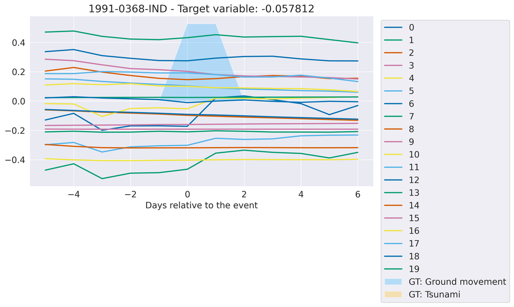

```python
#Chose an event
idx = 15

#print(len(regressor.train_loader.dataset.selected_events))

#for idx in np.arange(len(regressor.train_loader.dataset.selected_events)):
event_example = regressor.train_loader.dataset.selected_events.index[idx]

# Visualise chosen event
plot_event(regressor.train_loader.dataset, event_example)
```

We now visualise the distribution of the variable that we want to predict:

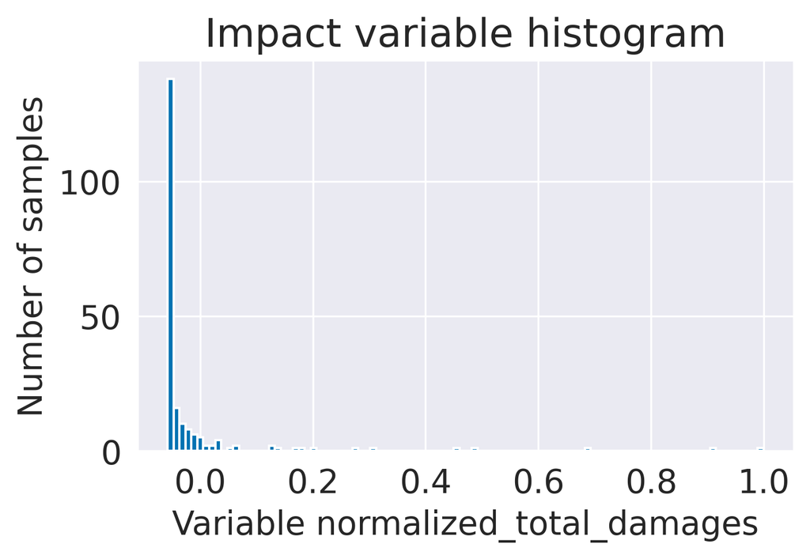

```python
# Plot the distribution of the impact variable that we want to predict
fig, axs = plt.subplots(1, 1, figsize=(5,3))
axs.set_title('Impact variable histogram')
axs.set_xlabel('Variable ' + regressor.train_loader.dataset.impacts.name)
axs.set_ylabel('Number of samples')
_ = axs.hist(regressor.train_loader.dataset.y, bins=100)
```

## 3. MODEL

Our input data is the set of selected climatological variables, which we explored in the previous section. To exploit the temporal information, we design a simple recurrent neural network. The core element is a Long Short-Term Memory cell, able of learning long-term dependencies between the data. After that, we concatenate two fully connected layers to further process the information.

[figure not shown]

According to the parameters of choice (see Section 2.2), our model's summary is as follows:

```python
regressor.implement_model()
regressor.model
```

[output not shown]

```
PytorchModel(
  (model): UD_LSTM_IA(
    (lstm): LSTM(20, 32, batch_first=True)
    (lstm_ln): LayerNorm((32,), eps=1e-05, elementwise_affine=True)
    (fc): Linear(in_features=32, out_features=16, bias=True)
    (fc_ln): LayerNorm((16,), eps=1e-05, elementwise_affine=True)
    (fc_top): Linear(in_features=16, out_features=1, bias=True)
    (dropout): Dropout(p=0.1, inplace=False)
  )
  (loss): HuberLoss()
)
```

## 4. TRAINING

We make use of TensorBoard to see how our model has learnt. The train_val_losses drop-down will show a graphic depicting the performance of our model during all training steps.

```python
# Load the TensorBoard notebook extension
%load_ext tensorboard

tensorboard_path = save_path / 'lightning_logs'

%tensorboard --logdir="$tensorboard_path" --port=6012
```

[interactive chart not shown]

> The first run of the tensorboard cell will provide a prompt saying "No dashboards are active for the current data set". This is the correct behaviour of the cell. Please, use the refresh symbol in the prompt once the training of the model has started (cell below) to follow in real time the learning process of the model.

```python
model= regressor.train()
```

```
Missing logger folder: /home/maria/Documents/AIDE_private/AIDE/experiments/jupyter_XAIDA_Earthquakes_1694256291.7084587/lightning_logs

  | Name          | Type       | Params
---------------------------------------------
0 | model         | UD_LSTM_IA | 7.6 K
1 | model.lstm    | LSTM       | 6.9 K
2 | model.lstm_ln | LayerNorm  | 64
3 | model.fc      | Linear     | 528
4 | model.fc_ln   | LayerNorm  | 32
5 | model.fc_top  | Linear     | 17
6 | model.dropout | Dropout    | 0
7 | loss          | HuberLoss  | 0
---------------------------------------------
7.6 K     Trainable params
0         Non-trainable params
7.6 K     Total params
0.030     Total estimated model params size (MB)
```

## 5. EVALUATION

For evaluating the model, we employ some of the most common metrics for regression tasks, available in the TorchMetrics library [Detlefsen, N. S., 2022]:

- Mean Squared Error (MSE): Signal fidelity measure that measures the average squared difference between the estimated values and the actual value. Range: [0, +inf], values closer to zero indicate better performance.
- Pearson Correlation Coefficient: Statistical measure of the linear correlation between two variables. Range: [-1,1], higher values indicate higher concordance between variables.
- Spearman Correlation Coefficient: Statistical measure of the strength of a monotonic relationship between paired data. Range: [-1,1], higher values indicate higher concordance between variables.

This list has been defined in the config file, evaluation section.

```python
regressor.test()
```

```
────────────────────────────────────────────────────────────────────────────────────────────────────────────────────────
       Test metric             DataLoader 0
────────────────────────────────────────────────────────────────────────────────────────────────────────────────────────
  test_MeanSquaredError    0.012496540322899818
  test_PearsonCorrCoef      0.2792527973651886
  test_SpearmanCorrCoef     0.4161713421344757
     test_loss_epoch       0.005564543418586254
────────────────────────────────────────────────────────────────────────────────────────────────────────────────────────
```

### Verification of results

For a better assessment of the model's performance, we visualise the predictions of our model in contraposition to the real values of the events that conform the test set (worldwide earthquakes comprised between 2015-2021).

```
Infering Dataloader: 100%|████████████████████████████████████████████████████████████████████████████████████████████████████████████████████████████████████████████████| 65/65 [00:00<00:00, 123.90it/s]
```

```
Prediction:  0.00097046 , Groundtruth:  5.95e-06
Prediction:  0.00636343 , Groundtruth:  0.00026736
Prediction:  0.00194929 , Groundtruth:  0.03340641
Prediction:  0.00642674 , Groundtruth:  0.0
Prediction:  0.00026819 , Groundtruth:  1.3e-06
Prediction:  0.01012827 , Groundtruth:  0.00026958
Prediction:  0.0098428 , Groundtruth:  0.00047497999999999996
Prediction:  0.00150219 , Groundtruth:  0.00110324
Prediction:  0.00603101 , Groundtruth:  0.00064717
Prediction:  0.0034506199999999997 , Groundtruth:  0.00043580999999999996
Prediction:  0.008312990000000001 , Groundtruth:  0.00012552
Prediction:  0.00198607 , Groundtruth:  0.0035738999999999996
Prediction:  0.00433769 , Groundtruth:  0.00654365
Prediction:  0.01026217 , Groundtruth:  0.01323092
Prediction:  0.00351557 , Groundtruth:  0.026366729999999998
Prediction:  0.015814170000000002 , Groundtruth:  0.00337781
Prediction:  0.0033751899999999997 , Groundtruth:  0.00015527
Prediction:  0.014835449999999998 , Groundtruth:  0.1694356
Prediction:  0.01473533 , Groundtruth:  0.05055859
Prediction:  0.0016438499999999999 , Groundtruth:  1.034e-05
Prediction:  0.0060726700000000005 , Groundtruth:  0.021995709999999998
Prediction:  0.00077359 , Groundtruth:  7.127e-05
Prediction:  0.00040242 , Groundtruth:  2.2300000000000002e-06
Prediction:  0.01149356 , Groundtruth:  0.00454709
Prediction:  0.015187039999999999 , Groundtruth:  1.092e-05
Prediction:  0.00811506 , Groundtruth:  0.0021135999999999998
Prediction:  0.00100408 , Groundtruth:  1.778e-05
Prediction:  0.0051971000000000005 , Groundtruth:  0.0005264299999999999
Prediction:  0.01146134 , Groundtruth:  0.00306652
Prediction:  0.00164437 , Groundtruth:  4.325e-05
Prediction:  0.00382826 , Groundtruth:  4.52e-06
Prediction:  0.00488591 , Groundtruth:  6e-07
Prediction:  0.006506509999999999 , Groundtruth:  0.00025791
Prediction:  0.00664641 , Groundtruth:  0.035108719999999996
Prediction:  0.00416623 , Groundtruth:  0.0028067599999999997
Prediction:  0.0039426 , Groundtruth:  0.00122546
Prediction:  0.01088672 , Groundtruth:  0.01285937
Prediction:  0.00295124 , Groundtruth:  1.628e-05
Prediction:  -0.0008002899999999999 , Groundtruth:  0.00363181
Prediction:  0.00587447 , Groundtruth:  0.00071623
```

[output cut: 10 more lines]

```
Prediction:  0.0014042 , Groundtruth:  1.3e-07
Prediction:  0.00462666 , Groundtruth:  0.00152468
Prediction:  -0.00582752 , Groundtruth:  0.00039185
Prediction:  0.0139784 , Groundtruth:  0.0009567
Prediction:  0.00591156 , Groundtruth:  0.00104522
Prediction:  0.01028509 , Groundtruth:  0.00373315
Prediction:  0.00947045 , Groundtruth:  0.01625901
Prediction:  0.00727966 , Groundtruth:  0.0028929100000000003
Prediction:  0.01104137 , Groundtruth:  0.00099832
Prediction:  0.00405477 , Groundtruth:  0.020151119999999998
Prediction:  0.00717497 , Groundtruth:  0.00219026
Prediction:  0.0076355500000000005 , Groundtruth:  3.598e-05
Prediction:  0.0017737800000000002 , Groundtruth:  0.00022579
Prediction:  0.01163593 , Groundtruth:  0.00125373
Prediction:  0.01259306 , Groundtruth:  0.01562514
```

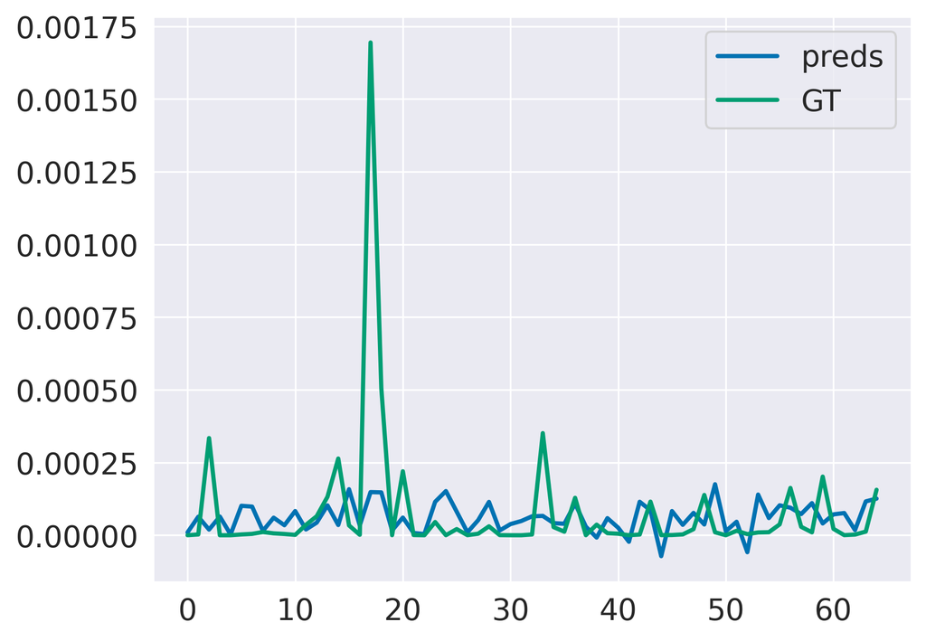

```python
regressor.config['evaluation']['xai']['activate'] = False
output_data= regressor.inference(subset='test')
scaler = regressor.test_loader.dataset.get_target_scaler()
all_pred = []
all_labels = []
for pred, label in zip(output_data['outputs'], output_data['labels']):
    pred = np.exp(scaler.inverse_transform(3*pred.reshape(-1, 1))) - 1
    label = np.exp(scaler.inverse_transform(3*label.reshape(-1, 1))) - 1
    #pred = np.exp(scaler.inverse_transform(pred.reshape(-1, 1))) - 1
    #label = np.exp(scaler.inverse_transform(label.reshape(-1, 1))) - 1
    all_pred.append(np.squeeze(pred))
    all_labels.append(np.squeeze(label))
    print('Prediction: ', round(pred.item(),10)*100, ', Groundtruth: ', round(label.item(),10)*100)

plt.plot(all_pred, label='preds')
plt.plot(all_labels, label='GT')
plt.legend()
```

## 6. EXPLAINABLE AI

To complete the assessment of our model, we activate the optional feature of the eXplainable AI (XAI) module. This module allows us to go beyond the intuitive understanding of the model's performance and gain insight into its inner workings. The backbone of this module is Python’s Captum library (https://captum.ai/) [Kokhlikyan et al., 2020], a well-known open-source library for model interpretability built on PyTorch, that efficiently implements the vast majority of the attribution methods proposed in the literature.

In this example, we select Saliency [Simonyan, 2013], one of the simplest attribution methods. This method is based on the computation of the gradient of the output with respect to the input.

```python
regressor.config['evaluation']['xai']['activate'] = True
regressor.config['evaluation']['xai']['type'] = 'Saliency'
xai_output= regressor.inference(subset='test')
```

```
Infering Dataloader: 100%|████████████████████████████████████████████████████████████████████████████████████████████████████████████████████████████████████████████████| 65/65 [00:00<00:00, 124.70it/s]
Explaining Dataloader: 100%|██████████████████████████████████████████████████████████████████████████████████████████████████████████████████████████████████████████████| 65/65 [00:00<00:00, 117.64it/s]
Visualizing explanations: 100%|████████████████████████████████████████████████████████████████████████████████████████████████████████████████████████████████████████████| 65/65 [03:01<00:00,  2.80s/it]
```

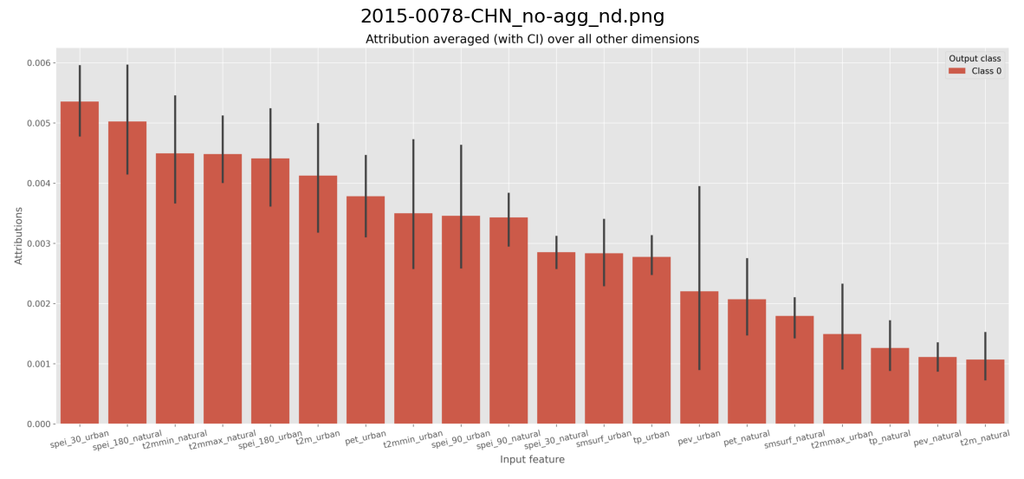

```python
# For one event plot side by side the XAI images obtained
event_name= xai_output['event_names'][0]
path= list((Path(regressor.config['save_path']) / 'xai').glob(f'{event_name}*.png'))

# First visualization result for the XAI module
img= np.asarray(Image.open(path[0]))
plt.figure(figsize=(15,15))
plt.imshow(img)
plt.axis(False);
plt.title(path[0].name)
plt.show()
```

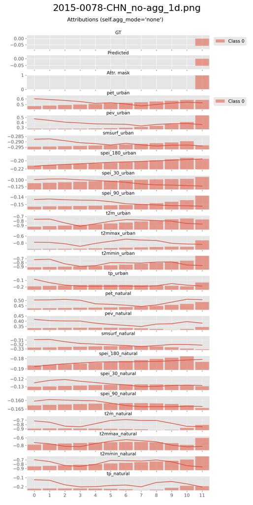

```python
# Second visualization result for the XAI module
img= np.asarray(Image.open(path[1]))
plt.figure(figsize=(15,15))
plt.imshow(img)
plt.axis(False);
plt.title(path[1].name)
plt.show()
```